# FigureYa284pairwiseLogrank

**Author(s)**: Xiaofan Lu; Yasi Zhang  
**Reviewer(s)**: Ying Ge  
**Date**: `r Sys.Date()`

# Academic Citation

If you use this code in your work or research, we kindly request that you cite our publication:

Xiaofan Lu, et al. (2025). FigureYa: A Standardized Visualization Framework for Enhancing Biomedical Data Interpretation and Research Efficiency. iMetaMed. https://doi.org/10.1002/imm3.70005

# 需求描述

# Requirements Description

希望画出文章里面Figure2的a。

We hope to draw a in Figure2 of the article.

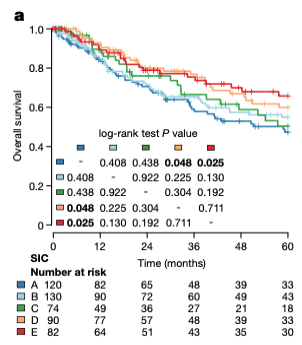

出自https://www.nature.com/articles/s41586-019-1906-8

Source: https://www.nature.com/articles/s41586-019-1906-8

# 应用场景

# Application Scenario

对3组及以上的亚组进行生存分析，并打印配对比较的统计表格。

参考：MOVICS包中compSurv()函数：https://github.com/xlucpu/MOVICS/blob/master/R/compSurv.R

Survival analysis for 3+ subgroups with pairwise comparison statistics table.

Reference: compSurv() function from MOVICS package https://github.com/xlucpu/MOVICS/blob/master/R/compSurv.R

# 环境设置

# Environment Setup

Using domestic mirrors for package installation.

```r
source("install_dependencies.R")
```

```
## Starting R package installation...
## ===========================================
##
## Installing CRAN packages...
## Package already installed: RColorBrewer
## Package already installed: ggpp
## Package already installed: survival
## Package already installed: survminer
## Package already installed: tibble
##
## ===========================================
## Package installation completed!
## You can now run your R scripts in this directory.
```

# 加载包

# Loading packages

```r
library(survival)
library(survminer)
library(RColorBrewer)
library(tibble)
library(ggpp)
# 显示英文报错信息
# Show English error messages
Sys.setenv(LANGUAGE = "en")

# 禁止chr转成factor
# Prevent character-to-factor conversion
options(stringsAsFactors = FALSE)
```

# 输入文件

# Input Files

```r
# 加载示例数据
# Load example data
dat <- read.table("easy_input.txt",sep = "\t",row.names = 1,check.names = F,stringsAsFactors = F,header = T)
```

# 生存分析

# Survival Analysis

```r
# 仿照原文将PAM50分型按照ABCDE标记
# Label PAM50 subtypes as A-E following the paper
dat$group <- sapply(dat$PAM50,function(x) {
  switch(x,
         "Basal"  = "A",
         "Her2"   = "B",
         "LumA"   = "C",
         "LumB"   = "D",
         "Normal" = "E")})

# 将生存时间转换为月份
# Convert survival time to months
dat$OS.time <- dat$OS.time * 12

# 生存分析
# Survival analysis
fitd <- survdiff(Surv(OS.time, OS) ~ group,
                 data      = dat,
                 na.action = na.exclude)
p.val <- 1 - pchisq(fitd$chisq, length(fitd$n) - 1)

# 拟合生存曲线
# Fit survival curves
fit <- survfit(Surv(OS.time, OS)~ group,
               data      = dat,
               type      = "kaplan-meier",
               error     = "greenwood",
               conf.type = "plain",
               na.action = na.exclude)

# 配对生存分析
# Pairwise survival analysis
ps <- pairwise_survdiff(Surv(OS.time, OS)~ group,
                        data            = dat,
                        p.adjust.method = "none")
```

# 开始画图

# Start Plotting

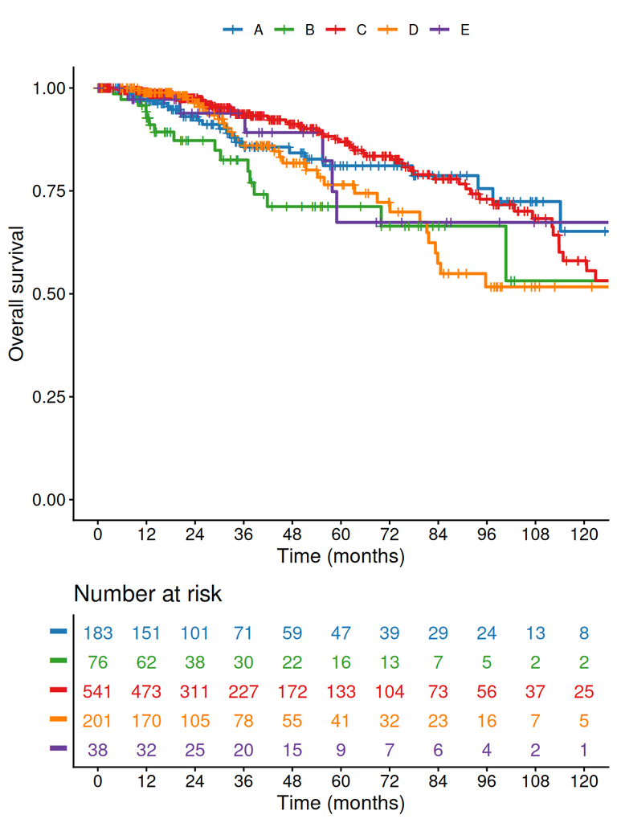

```r
# 设置颜色
# Set colors
mycol <- brewer.pal(n = 10, "Paired")[c(2,4,6,8,10)]

# 绘制基础图形
# Draw the basic graphics

## 隐藏类标记
## Remove "group=" prefix
names(fit$strata) <- gsub("group=", "", names(fit$strata))

## 生存曲线图
## Survival curve plot
p <- ggsurvplot(fit               = fit,
                # 不绘制置信区间
                # No confidence intervals
                conf.int          = FALSE,
                # 生存风险表
                #Show risk table
                risk.table        = TRUE,
                risk.table.col    = "strata",
                # KM曲线颜色
                # KM curve colors
                palette           = mycol,
                data              = dat,
                # 时间轴，一般考虑5年（原文）或者10年长度
                # Time axis (5-10 year range)
                xlim              = c(0,120),
                size              = 1,
                # 时间轴的刻度（每年）
                # Tick marks (annual)
                break.time.by     = 12,
                legend.title      = "",
                xlab              = "Time (months)",
                ylab              = "Overall survival",
                risk.table.y.text = FALSE,
                # 风险表的高度
                # Risk table height
                tables.height     = 0.3)
p
```

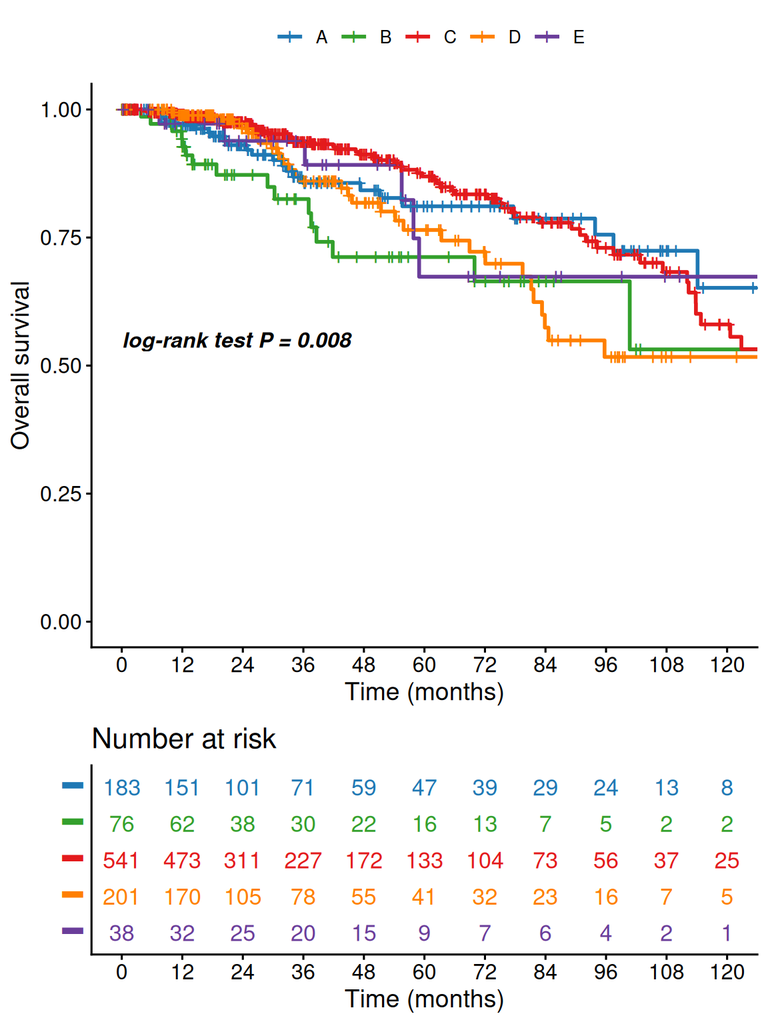

```r
## 添加overall p value
## Add overall p-value
p.lab <- paste0("log-rank test P",
                ifelse(p.val < 0.001, " < 0.001",
                       paste0(" = ",round(p.val, 3))))

p$plot <- p$plot + annotate("text",
                            x = 0, y = 0.55,
                            hjust = 0,
                            fontface = 4,
                            label = p.lab)
p
```

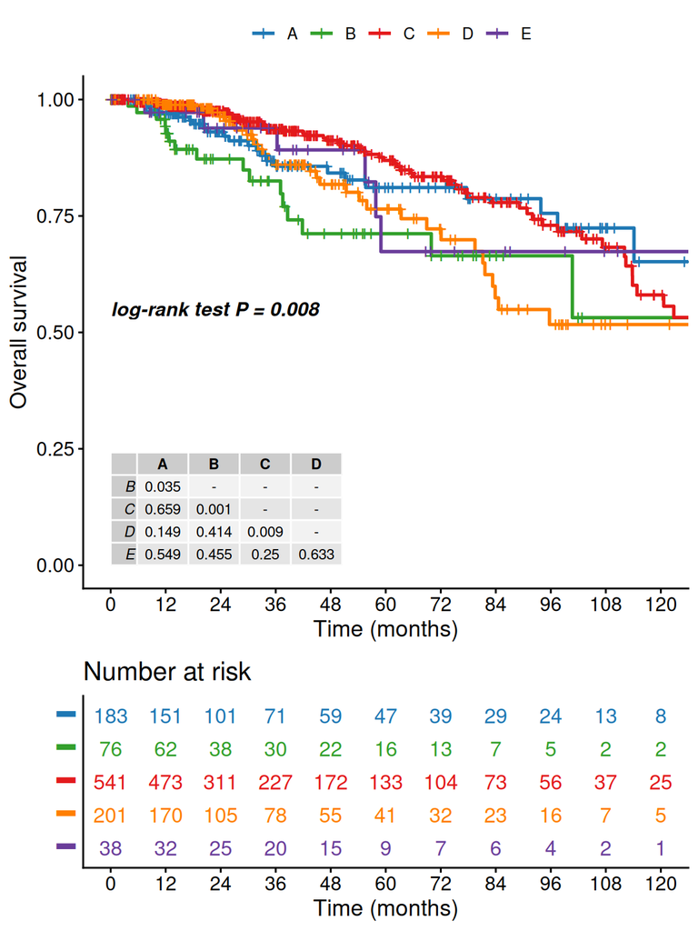

```r
## 添加配对表格
## Add pairwise comparison table
addTab <- as.data.frame(as.matrix(ifelse(round(ps$p.value, 3) < 0.001, "<0.001",
                                         round(ps$p.value, 3))))
addTab[is.na(addTab)] <- "-"
df <- tibble(x = 0, y = 0, tb = list(addTab))
p$plot <- p$plot +
  geom_table(data = df,
             aes(x = x, y = y, label = tb),
             table.rownames = TRUE)
p
```

```r
# 输出图像
# Save plot
pdf.options(reset = TRUE, onefile = FALSE)
pdf("km curve with pairwise logrank test.pdf", width = 4.5, height = 6)
print(p)
dev.off()
```

# 会话信息